# **EDA Danych dotyczących Titanica**

## O Danych

Dane o pasażerach Titanica

Zbiór danych zawiera informacje o pasażerach RMS Titanic, który zatonął 15 kwietnia 1912 roku po zderzeniu z górą  
lodową. Dane obejmują takie atrybuty jak klasa podróży, wiek, płeć, liczba rodzeństwa/małżonków na pokładzie,  
liczba rodziców/dzieci na pokładzie, cena biletu oraz miejsce zaokrętowania.

Zbiór zawiera także informację o tym, czy pasażer przeżył katastrofę.

Titanic przewoził ponad 2,200 osób, z czego ponad 1,500 zginęło, co czyni tę katastrofę jedną z najbardziej  
tragicznych w historii morskiej.

Kolumny:

- **pclass** - Klasa biletu
- **survived** - Czy pasażer przeżył katastrofę
- **name** - Imię i nazwisko pasażera
- **sex** - Płeć pasażera
- **age** - Wiek pasażera
- **sibsp** - Liczba rodzeństwa/małżonków na pokładzie
- **parch** - Liczba rodziców/dzieci na pokładzie
- **ticket** - Numer biletu
- **fare** - Cena biletu
- **cabin** - Numer kabiny
- **embarked** - Port, w którym pasażer wszedł na pokład (C = Cherbourg, Q = Queenstown, S = Southampton)
- **boat** - Numer łodzi ratunkowej
- **body** - Numer ciała (jeśli pasażer nie przeżył i ciało zostało odnalezione)
- **home.dest** - Miejsce docelowe

## A. Wcztywanie danych i ogólny przegląd danych

|  | pclass | survived | name | sex | age | sibsp | parch | ticket | fare | cabin | embarked | boat | body | home.dest |
| --- | --- | --- | --- | --- | --- | --- | --- | --- | --- | --- | --- | --- | --- | --- |
| 0 | 1.0 | 1.0 | Allen, Miss. Elisabeth Walton | female | 29.0000 | 0.0 | 0.0 | 24160 | 211.3375 | B5 | S | 2 | NaN | St Louis, MO |
| 1 | 1.0 | 1.0 | Allison, Master. Hudson Trevor | male | 0.9167 | 1.0 | 2.0 | 113781 | 151.5500 | C22 C26 | S | 11 | NaN | Montreal, PQ / Chesterville, ON |
| 2 | 1.0 | 0.0 | Allison, Miss. Helen Loraine | female | 2.0000 | 1.0 | 2.0 | 113781 | 151.5500 | C22 C26 | S | NaN | NaN | Montreal, PQ / Chesterville, ON |
| 3 | 1.0 | 0.0 | Allison, Mr. Hudson Joshua Creighton | male | 30.0000 | 1.0 | 2.0 | 113781 | 151.5500 | C22 C26 | S | NaN | 135.0 | Montreal, PQ / Chesterville, ON |
| 4 | 1.0 | 0.0 | Allison, Mrs. Hudson J C (Bessie Waldo Daniels) | female | 25.0000 | 1.0 | 2.0 | 113781 | 151.5500 | C22 C26 | S | NaN | NaN | Montreal, PQ / Chesterville, ON |
| ... | ... | ... | ... | ... | ... | ... | ... | ... | ... | ... | ... | ... | ... | ... |
| 1305 | 3.0 | 0.0 | Zabour, Miss. Thamine | female | NaN | 1.0 | 0.0 | 2665 | 14.4542 | NaN | C | NaN | NaN | NaN |
| 1306 | 3.0 | 0.0 | Zakarian, Mr. Mapriededer | male | 26.5000 | 0.0 | 0.0 | 2656 | 7.2250 | NaN | C | NaN | 304.0 | NaN |
| 1307 | 3.0 | 0.0 | Zakarian, Mr. Ortin | male | 27.0000 | 0.0 | 0.0 | 2670 | 7.2250 | NaN | C | NaN | NaN | NaN |
| 1308 | 3.0 | 0.0 | Zimmerman, Mr. Leo | male | 29.0000 | 0.0 | 0.0 | 315082 | 7.8750 | NaN | S | NaN | NaN | NaN |
| 1309 | NaN | NaN | NaN | NaN | NaN | NaN | NaN | NaN | NaN | NaN | NaN | NaN | NaN | NaN |

1310 rows × 14 columns

```
<class 'pandas.core.frame.DataFrame'>
RangeIndex: 1310 entries, 0 to 1309
Data columns (total 14 columns):
 #   Column     Non-Null Count  Dtype
---  ------     --------------  -----
 0   pclass     1309 non-null   float64
 1   survived   1309 non-null   float64
 2   name       1309 non-null   object
 3   sex        1309 non-null   object
 4   age        1046 non-null   float64
 5   sibsp      1309 non-null   float64
 6   parch      1309 non-null   float64
 7   ticket     1309 non-null   object
 8   fare       1308 non-null   float64
 9   cabin      295 non-null    object
 10  embarked   1307 non-null   object
 11  boat       486 non-null    object
 12  body       121 non-null    float64
 13  home.dest  745 non-null    object
dtypes: float64(7), object(7)
memory usage: 143.4+ KB
```

```
pclass          3
survived        2
name         1307
sex             2
age            98
sibsp           7
parch           8
ticket        929
fare          281
cabin         186
embarked        3
boat           27
body          121
home.dest     369
dtype: int64
```

|  | pclass | survived | age | sibsp | parch | fare | body |
| --- | --- | --- | --- | --- | --- | --- | --- |
| count | 1309.000000 | 1309.000000 | 1046.000000 | 1309.000000 | 1309.000000 | 1308.000000 | 121.000000 |
| mean | 2.294882 | 0.381971 | 29.881135 | 0.498854 | 0.385027 | 33.295479 | 160.809917 |
| std | 0.837836 | 0.486055 | 14.413500 | 1.041658 | 0.865560 | 51.758668 | 97.696922 |
| min | 1.000000 | 0.000000 | 0.166700 | 0.000000 | 0.000000 | 0.000000 | 1.000000 |
| 25% | 2.000000 | 0.000000 | 21.000000 | 0.000000 | 0.000000 | 7.895800 | 72.000000 |
| 50% | 3.000000 | 0.000000 | 28.000000 | 0.000000 | 0.000000 | 14.454200 | 155.000000 |
| 75% | 3.000000 | 1.000000 | 39.000000 | 1.000000 | 0.000000 | 31.275000 | 256.000000 |
| max | 3.000000 | 1.000000 | 80.000000 | 8.000000 | 9.000000 | 512.329200 | 328.000000 |

### Wnioski

1. Baza danych składa się z 1310 wierszy i 14 kolumn (7 z liczbami zmiennoprzecinkowymi i 7 z danymi tekstowymi)
2. Wiersz o indeksie 1309 nie zawiera żadnych danych, więc został usunięty
3. Wyróżniono 3 klasy biletów, 3 porty, w których pasażerowie wsiedli na statek i 27 różnych numerów łodzi ratunkowych (co dziwne, bo jak sprawdziłem mieli ich tylko 20)
4. Najstarszy pasażer miał 80 lat
5. Najwieksza rodzina miała dziwięcioro dzieci
6. Najdroższy bilet kosztował 512,33

## B. Analiza brakujących wartości

```
pclass          0
survived        0
name            0
sex             0
age           263
sibsp           0
parch           0
ticket          0
fare            1
cabin        1014
embarked        2
boat          823
body         1188
home.dest     564
dtype: int64
```

|  | pclass | count |
| --- | --- | --- |
| 0 | 1.0 | 67 |
| 1 | 2.0 | 254 |
| 2 | 3.0 | 693 |

## C. Analiza pojedynczych zmiennych i transformacja danych

### 1. Klasy biletów

|  | klasa | liczba |
| --- | --- | --- |
| 1 | 1 | 323 |
| 2 | 2 | 277 |
| 0 | 3 | 709 |

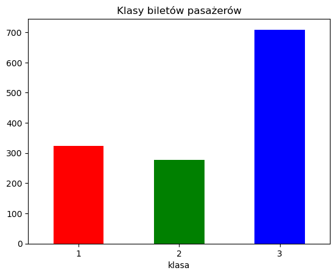

#### Wnioski

- Pasażerów z biletami pierwszej klasy było 323, drugiej klasy 277 a trzeciej klasy 709
- Pasażerów trzeciej klasy było więcej, niż pierwszej i drugiej razem

### 2. Przeżywalność

|  | przeżywalność | liczba | procent |
| --- | --- | --- | --- |
| 0 | martwi | 809 | 61.8 |
| 1 | żywi | 500 | 38.2 |

|  | płeć | survived | liczba | procent |
| --- | --- | --- | --- | --- |
| 0 | female | 0.0 | 127 | 27.3 |
| 1 | female | 1.0 | 339 | 72.7 |
| 2 | male | 0.0 | 682 | 80.9 |
| 3 | male | 1.0 | 161 | 19.1 |

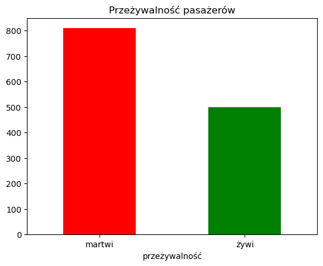

#### Wnioski

Katastrofę przeżyło 500 pasażerów, czyli 38,2% a zginęło 809, czyli 61,8%

### 3. Nazwiska pasażerów

|  | liczba nazwisk | liczba pasażerów | suma pasażerów |
| --- | --- | --- | --- |
| 0 | 1 | 637 | 637 |
| 1 | 2 | 133 | 266 |
| 2 | 3 | 63 | 189 |
| 3 | 4 | 22 | 88 |
| 4 | 6 | 9 | 54 |
| 5 | 5 | 6 | 30 |
| 6 | 11 | 2 | 22 |
| 7 | 8 | 2 | 16 |
| 8 | 7 | 1 | 7 |

|  | pasażerowie | liczba pasażerów |
| --- | --- | --- |
| 0 | "samotni" | 637 |
| 1 | "z rodzinami" | 672 |

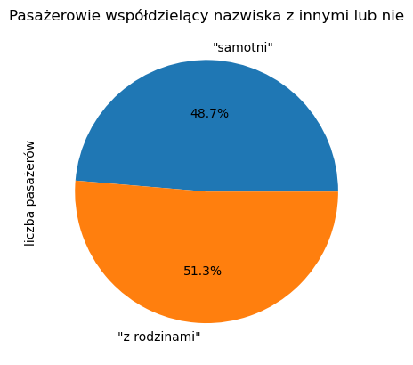

#### Wnioski

- wszystkich pasażerów było 1309
- pasażerowie mieli 875 różnych nazwisk
- najwięcej pasażerów nosiło nazwiska Andersson i Sage, po 11 osób
- 637 pasażerów (48,7 %) nie dzieliło nazwiska z nikim innym, a pozostali 672 (51,3 %) podróżowali z kimś o takim samym nazwisku (byc może z rodziną)

### 4. "Tytuły" pasażerów

#### Wnioski

- każdy z 1309 pasażerów posiadał jakiś "tytuł"
- najbardziej popularne "tytuły" wśród pasażerów: to Mr - Pan (757), Miss - Panna (260), Mrs - Pani (197) i Master - Mistrz/Pan (61)

### 5. Nazwiska rodowe pasażerów

#### Wnioski

- 181 pasażerów miało nazwiska rodowe, w tym 178 kobiet i 3 mężczyzn
- unikatowych nazwisk rodowych było 169, z czego 45 wystąpiło wśród nazwisk pasażerów

### 6. Płeć

|  | płeć | liczba pasażerów |
| --- | --- | --- |
| 0 | mężczyźni | 843 |
| 1 | kobiety | 466 |

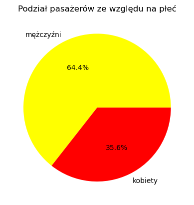

#### Wnioski

- wśród pasażerów było 843 mężczyz i 466 kobiet
- mężczyźni stanowili 64,4% pasażerów a kobiety 35,6%

### 7. Wiek

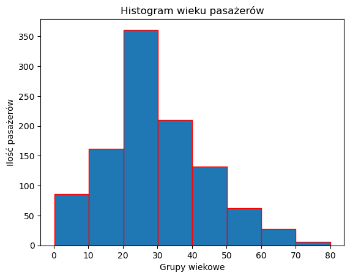

|  | age_group | 0 |
| --- | --- | --- |
| 0 | dorośli | 892 |
| 1 | dzieci | 154 |

### 8. Bilety, służba i rodziny

#### Wnioski cz. 1

```
sex
female    18
male       5
dtype: int64
```

#### Wnioski cz. 2

- na pokładzie było 23 służących, znamy wiek 20 z nich i wynosił od 22 lat, do 58 lat
- wśród służących było 5 mężczyzn i 18 niezamężnych kobiet (określenie Dona stosowane było raczej do panien)

### 9. Ceny biletów

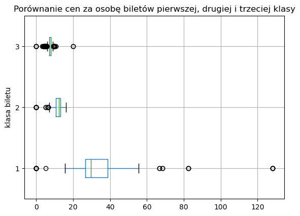

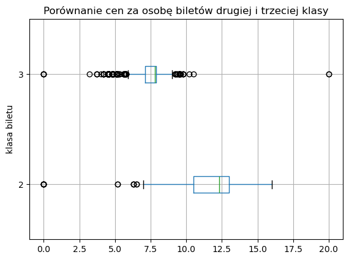

### 10. Numery kabiny

|  | pclass | 0 |
| --- | --- | --- |
| 0 | 1 | 256 |
| 1 | 2 | 23 |
| 2 | 3 | 16 |

#### Wnioski

- jedynie 295 pazsażerów ma przypisane kabiny
- kabiny są przypisane do 256 pasażerów z biletami pierwszej klasy, 23 z drugiej klasy i 16 z trzeciej klasy
- oznaczenie kabiny skałada się z dużej litery alfabetu i dołączonej liczby, pierwsze litery alfabetu i niższe liczby świadczą zwykle o wyższej klasie biletu
- niektórzy pasażerowie z biletami pierwszej klasy mają przypisanych kilka kabin

### 11. Port początkowy

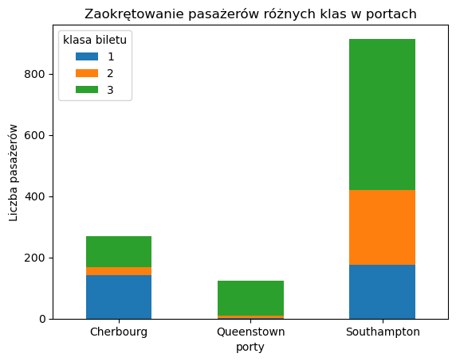

#### Wnioski

- znamy port zaokrętowania 1307 pasażerów
- najwięcej pasażerów weszło na pokład w Southampton - 914, najmniej w Queenstown - 123, a w Cherbourg - 270
- pasażerowie z biletami pierwszej klasy weszli na pokład głównie w Cherbourg i w Southampton
- w Queenstown zaokrętowali w zasadzie jedynie pasażerowie trzeciej klasy
- w Southampton zaokrętowali głównie pasażerowie drugiej i trzeciej klasy

### 12. Łodzie ratunkowe

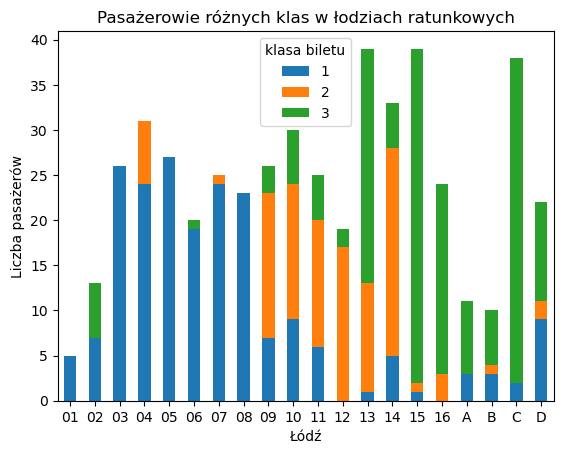

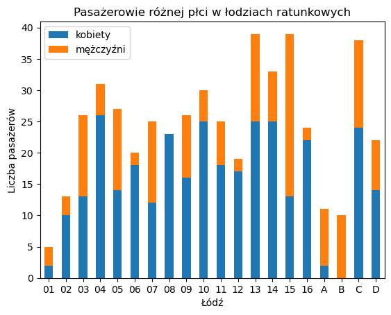

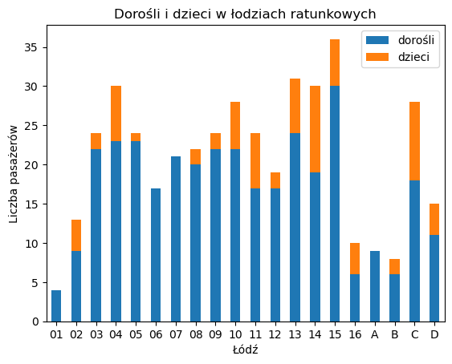

#### Wnioski

- 486 pasażerów ma przypisane miejsca w łodziach ratunkowych
- łodzi ratunkowych było 20, 16 opisanych kolejnymi numerami od 1 do 16 i 4 oznaczone dużymi litarami od A do D
- w łodziach znajdowało się od 5 do 39 pasażerów, średnio 24,3 pasażera, mediana wynosiła 25
- łodzie o numerach od 1 do 8 zajmowali głównie pasażerowie pierwszej klasy
- wiekszość pasażerów drugiej klasy zajmowało łodzie o numerach od 9 do 14
- pasażerowie trzeciej klasy zajmowali łodzie numer 13, 15 i 16 oraz te oznaczone litarami alfabetu
- w większości łodzi kobiety stanowiły ponad połowę pasażerów
- w łodzi numer 8 były same kobiety a w łodzi B sami mężczyźni
- w wiekszości łodzi znajdowały się dzieci

### 13. Ciała pasażerów

|  | ciała | liczba pasażerów |
| --- | --- | --- |
| 0 | zaginione | 688 |
| 1 | odnalezione | 121 |

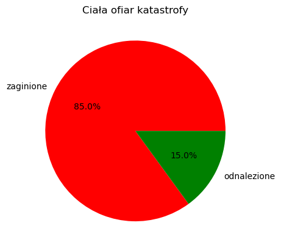

#### Wnioski

- odnaleziono i ponumerowano ciała 121 ofiar katastrofy
- wśród odnalezionych ciał było 8 kobiet i pięcioro dzieci
- odnaleziono ciała 15% wszystkich ofiar, ciała 688 ofiar nie zostały odnalezione

### 14. Miejsca docelowe

|  | home.dest | count |
| --- | --- | --- |
| 0 | New York, NY | 64 |
| 1 | London | 14 |
| 2 | Montreal, PQ | 10 |
| 3 | Paris, France | 9 |
| 4 | Cornwall / Akron, OH | 9 |

#### Wnioski

- 745 pasażerów miało podane miejsce docelowe
- unikatowych miejsc docelowych było 369
- najczęstszymi miejscami docelowymi był "New York, NY" - 64 osoby, "London" - 14 osób i "Montreal, PQ" - 10 osób

## D. Analiza relacji między zmiennymi - pytania

### 1. Czy hasło "ratujemy najpierw kobiety i dzieci" zadziałało?

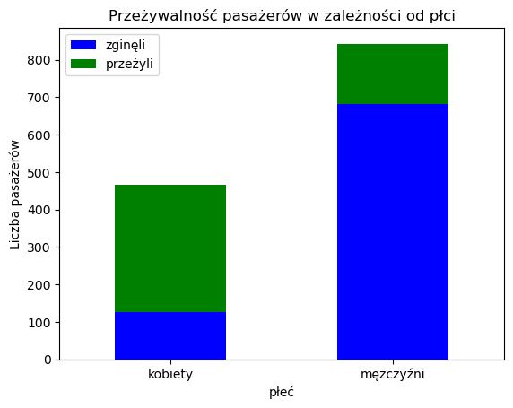

#### Wnioski cz.1

- katastrofę przeżyło 339 kobiet, co stanowi 72,7% wszystkich kobiet wśród pasażerów
- katastrofę przeżyło jedynie 161 mężczyzn, co stanowi 19,1% wszystkich mężczyzn wśród pasażerów
- biorąc pod uwagę wartości procentowe, katastrofę przeżyło prawie 4 razy więcej kobiet, niż mężczyzn

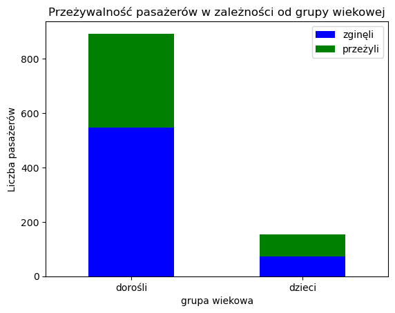

#### Wnioski cz.2

- z pasażerów dorosłych, których znamy wiek (892 osób) przeżyło 346, czyli 38,8%
- z dzieci, których znamy wiek (154 osoby) przeżyło 81, czyli 52,6%
- biorąc pod uwagę wartości procentowe, dzieci przeżyło niewiele więcej niż pasażerów dorosłych

### 2. Czy klasa biletu miała wpływ na przeżywalność?

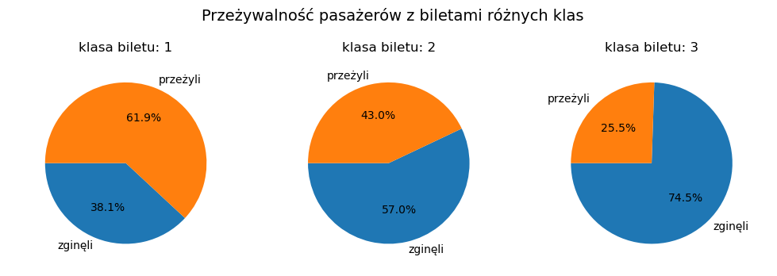

#### Wnioski cz.1

- z 323 pasażerów z biletami pierwszej klasy przeżyło 200, czyli 61,9%
- z 277 pasażerów z biletami drugiej klasy przeżyło 119, czyli 43%
- z 709 pasażerów z biletami trzeciej klasy przeżyło 181, czyli 25,5%
- porównując wartości procentowe, pasażerów klasy pierwszej przeżyło o połowę więcej niż klasy drugiej i ponad dwa razy więcj, niż klasy trzeciej

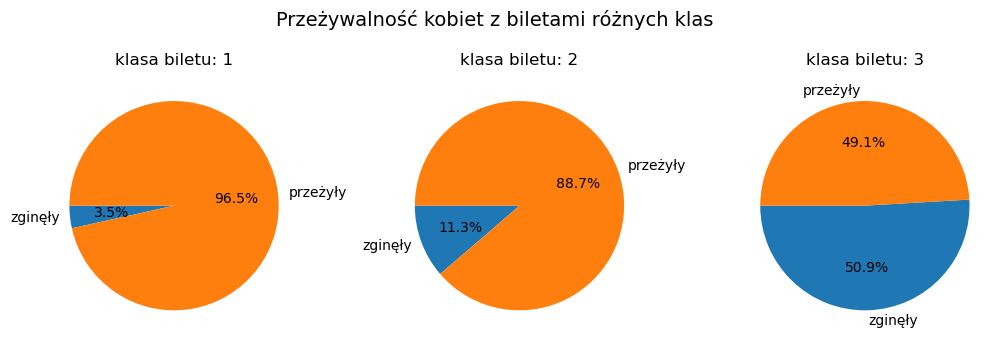

#### Wnioski cz.2

- ze 144 kobiet z biletami pierwszej klasy przeżyło 139, czyli 96,5%
- ze 106 kobiet z biletami drugiej klasy przeżyły 94, czyli 88,7%
- z 216 kobiet z biletami trzeciej klasy przeżyło 106, czyli 49,1%
- kobiety z biletami klasy pierwszej i drugiej przeżyły prawie wszystkie
- z kobiet z biletami klasy trzeciej przeżyło nieco mniej niż połowa

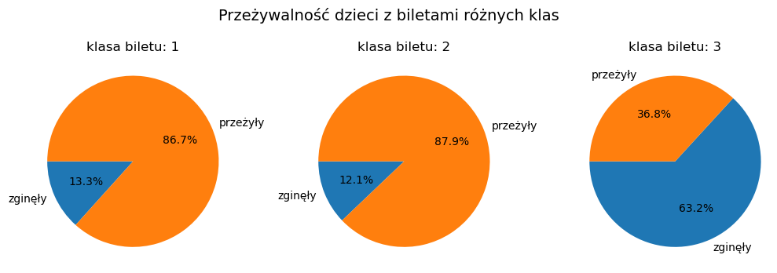

#### Wnioski cz.3

- z 15 dzieci z biletami pierwszej klasy przeżyło 13, czyli 86,7%
- z 33 dzieci z biletami drugiej klasy przeżyło 29, czyli 87,9%
- ze 106 dzieci z biletami trzeciej klasy przeżyło tylko 39, czyli 36,8%
- dzieci z biletami klasy pierwszej i drugiej przeżyły prawie wszystkie
- z dzieci z biletami klasy trzeciej przeżyło nieco więcej niż 1/3

### 3. Jak przeżywalność zależała od wieku pasażerów?

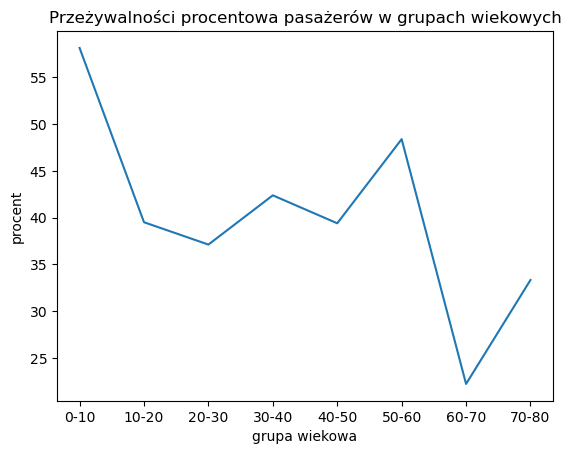

#### Wnioski

- najwiekszą przeżywalność miały dzieci w wieku do 10 lat - 58%
- kolejne grupy wiekowe 10-60 lat miały podobną przeżywalność w zakresie 37-48% z niewielkim trendem wzrostowym
- w grupach wiekowych 60-80 lat przeżywalność była bardzo niska 22-33%, jednak w grupie tej znajdowało się mało pasażerów (tylko 33)

### 4. Czy rodziny spotkał taki sam los, co osoby niespokrewnione?

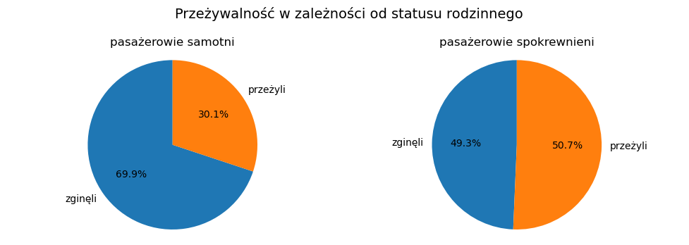

#### Wnioski

- z 794 pasażerów niespokrewnionych przeżyło 239, czyli 30,1%
- z 515 pasażerów spokrewnionych przeżyło 261, czyli 50,7%
- pasażerów spokrewnionych przeżyło znacznie więcej niż niespokrewnionych, prawdopodobnie z powodu większej obecności małych dzieci w tej grupie

### 5. Czy na przeżywalność dzieci miało wpływ posiadanie krewnych?

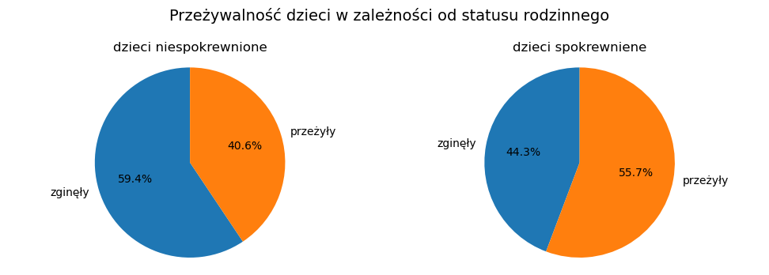

#### Wnioski

- z 32 dzieci niespokrewnionych przeżyło 13, czyli 40,6%
- ze 122 dzieci spokrewnionych przeżyło 68, czyli 55,7%
- status rodzinny dzieci miał nieduży wpływ na ich przeżywalność

### 7. Jaki był los służących i ich "rodzin"?

#### Wnioski

- z grupy 23 służących przeżyło aż 20, czyli 87%
- 19 służących trafiło do łodzi ratunkowych razem z członkami "swoich rodzin"
- w rodzinie państwa Allison zginęli wszyscy oprócz niespełna rocznego synka uratowanego przez służącą - pannę Cleaver w łodzi nr 11

### 8. Czy miejsce w szalupie oznaczało ratunek?

#### Wnioski

- trafienie do szalupy nie gwarantowało przeżycia katastrofy
- 9 pasażerów, którzy trafili do różnych łodzi ratunkowych nie przeżyło katastrofy

## E. Wnioski końcowe

- z 1309 pasażerów katastrofę przeżyło 38,2% (500 osób) a zginęło 61,8% (809 osób)

### "Najpierw kobiety i dzieci" - ogólna zasada ewakuacji podczas katastrof

- w przypadku kobiet zasada ta zadziałała, ponieważ procentowo przeżyło ich prawie 4 razy więcej, niż mężczyzn
- w przypadku dzieci zasada ta nie zadziałała dobrze, ponieważ przeżyło ich 53% a dorosłych 39%
- jednak największa przeżywalność była w grupie wiekowej do 10 r.ż., bo aż 58%

### Pasażerowie w różnych klasach

##### Klasa biletu miała ogromny wpływ na losy pasażerów

- kobiety z klasy pierwszej i drugiej przeżyły prawie wszystkie, tymczasem z klasy trzeciej przeżyło nieco mniej niż połowa
- również dzieci z klasy pierwszej i drugiej przeżyły prawie wszystkie a z klasy trzeciej przeżyła jedynie 1/3
- podczas zajmowania miejsc w łodziach ratunkowych widać było wyraźny podział na klasy

### Bohaterska służąca

W rodzinie państwa Allison zginęli wszyscy oprócz niespełna rocznego chłopca uratowanego przez służącą - pannę Cleaver w łodzi nr 11